# Metropolis Hastings

## General Metropolis-Hastings

For a given target density *f* we wish to estimate, we build a Markov kernel *K* with stationary distribution *f* and then generate a Markov chain \(X_t\) using this kernel so that the limiting distribution of the Markov chain is *f* and integrals can be approximated according to the *Ergodic Theorem*.

The **Metropolis-Hastings algorithm** is a general purpose MCMC method for approximating a target density *f*, using a conditional density \(q(y | x)\) that is easy to simulate from.

In addition, \(q\) can be almost arbitrary in that the only theoretical requirements are that the ratio \(\frac{f(y)}{q(y | x)}\) is known up to a constant *independent* of \(x\) and that \(q( \cdot | x )\) has enough dispertion to lead to an exploration of the entire support of *f*

We can rely on the feature of Metropolis-Hatings algorithm that for every given *q*, we can then construct a Metropolis-Hastings kernel such that *f* is its stationary distribution.

## General Metropolis-Hastings

The Metropolis-Hastings algorithm as described Robert & Casella goes as follows

Given \(x^{(t)}\)

`1. Generate` \(Y_t \sim q(y | x_t )\)

`2. Take` \[ X_{t+1} = \begin{cases} Y_t & \quad \text{with probability }\ \rho(x^{(t)}, Y_t) \\ x^{(t)} & \quad \text{with probability }\ 1 - \rho(x^{(t)}, Y_t) \\ \end{cases} \] where \[ \displaystyle \rho(x^{(t)}, Y_t) = \text{min} \left\{ \frac{f(Y_t)}{f(x^{(t)})} \frac{q(x^{(t)} | Y_t)}{q(Y_t | x^{(t)})} , 1 \right\} \]

## General Metropolis-Hastings

In simpler terms, as we want to generate \(X \sim f\), we first take an initial value \(x^{(0)}\) (which can almost be any artibrary value in the support of \(f\)).

1. We generate a value \(Y_0 \sim q(y | x^{(0)})\).
2. We calculate \(\rho(x^{(t)}, Y_t)\)
3. Generate a random value \(U \sim Unif(0,1)\)
4. If \(U < \rho(x^{(t)}, Y_t)\), then we accept \(X^{(1)} = Y_t\); else we take \(X^{(1)} = X^{(0)}\)
5. Repeate steps 1-4 until you've satisfied the number of samples needed

## General Metropolis-Hastings

You may notice the MH algorithm is not too dissimilar from the Accept-Reject algorithm.

`1. Generate` \(Y \sim g\), \(U \sim Unif(0,1)\)

`2. Accept` \(X = Y\) `if` \(U \leq \frac{f(Y)}{M g(Y)}\) ;

`3. Return to step 1 otherwise`

## Example Beta(2.7, 6.3)

As of now, we've covered multiple ways of generating random samples from a target density. Let us compare the accept-reject algorithm once more with the Metropolis-Hastings algorithm. Generate \(N\) samples from \(Beta(2.7, 6.3)\)

In order to use the accept-reject algorithm, we need a candidate distribution to sample from. Below are a set of potential candidate distributions.

[figure not shown]

## Example Beta(2.7, 6.3)

```r
## potential instumential distributions
curve(expr = dbeta(x, 2.7, 6.3), from = 0, to = 2)
curve(expr = dbeta(x, 3, 6), from = 0, to = 2, add = TRUE, col = 2, lty = 2)
curve(expr = dexp(x, rate = 3), from = 0, to = 2, add = TRUE, col = 3, lty = 2)
curve(expr = dnorm(x, mean = 0.25, 0.25), from = -2, to = 2, add = TRUE, col = 4, lty = 2)
curve(expr = dgamma(x, shape = 2.5, scale = 1/5), from = 0, to = 2, add = TRUE, col = 6, lty = 2)
legend(x = 1.2, y = 2.5, legend = c("Beta(2.7, 6.3)", "Beta(3, 6)", "Exp(1)", "N(0.25, 0.25)", "Gamma(2.5, 5)"),
       lty = c(1, 2, 2, 2, 2), col = c(1:4, 6), merge = TRUE)
```

## Example Beta(2.7, 6.3)

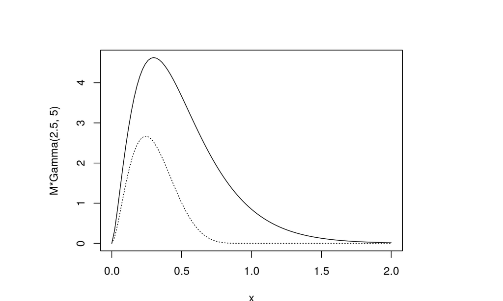

```r
M = 3
par(pin = c(4.5, 3))
curve(expr = M*dgamma(x, shape = 2.5, scale = 1/5), from = 0, to = 2, ylab = "M*Gamma(2.5, 5)")
curve(expr = dbeta(x, 2.7, 6.3), from = 0, to = 2, add = TRUE, lty = 3)
```

## Example Beta(2.7, 6.3)

```r
set.seed(1234)
N = 500000
## For accept-reject, we need to find a value for M

f = function(x){
  dbeta(x, 2.7, 6.3)
}

g = function(x){
  dgamma(x, shape = 2.5, scale = 1/5)
}
```

## Example Beta(2.7, 6.3)

```r
X = numeric(N)
i = 0
while(i < N){
  Y = rgamma(n = 1, shape = 2.5, scale = 1/5)
  U = runif(n = 1)
  if(U*M <= f(Y)/g(Y)){
    i = i + 1
    X[i] = Y
  }
}

qbeta(p = c(0, 0.25, 0.5, 0.75, 1), shape1 = 2.7, shape2 = 6.3) ## quantiles from Beta(2.7, 6.3)
```

```
## [1] 0.0000000 0.1895571 0.2846608 0.3950333 1.0000000
```

```r
quantile(X) ## sample mean from Accept-Reject samples
```

```
##         0%        25%        50%        75%       100%
## 0.00117328 0.18979491 0.28480053 0.39559864 0.94743365
```

## Example Beta(2.7, 6.3)

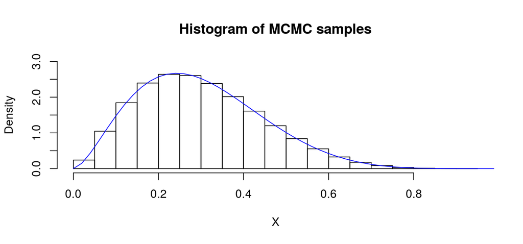

```r
## see how samples from chain compare to Beta(2.7, 6.3) density
hist(X, main = "Histogram of MCMC samples", prob = TRUE, ylim = c(0, 3))
curve(expr = dbeta(x, 2.7, 6.3),  from = 0, to = 2, add = TRUE, col = "blue")
```

## Example Beta(2.7, 6.3)

Below is the Metropolis-Hastings implementation for this problem.

```r
X = numeric(N)
X[1] = rbeta(n = 1, shape1 = 2.7, shape2 = 6.3) ## initial value
for(i in 1:N){
  Y = rgamma(n = 1, shape = 2.5, scale = X[i])  #rexp(n = 1, rate = X[i])
  rho = (dbeta(x = Y, 2.7, 6.3) * dgamma(x = X[i], shape = 2.5, scale = Y) ) /
    (dbeta(x = X[i], 2.7, 6.3) * dgamma(x = Y, shape = 2.5, scale = X[i])  )

  if(runif(1) < rho){
    X[i+1] = Y
  } else{
    X[i+1] = X[i]
  }
}
qbeta(p = c(0, 0.25, 0.5, 0.75, 1), shape1 = 2.7, shape2 = 6.3) ## quantiles from Beta(2.7, 6.3)
```

```
## [1] 0.0000000 0.1895571 0.2846608 0.3950333 1.0000000
```

```r
quantile(X) ## sample mean from M-H samples
```

```
##          0%         25%         50%         75%        100%
## 0.002143683 0.189484732 0.283584815 0.392688753 0.914997756
```

## Example Beta(2.7, 6.3)

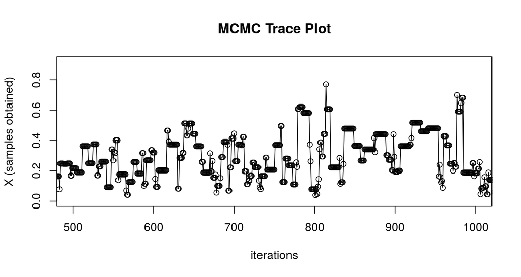

```r
plot(X, type = "o", main = "MCMC Trace Plot", xlim = c(500,1000),
     xlab = "iterations", ylab = "X (samples obtained)")
```

## Example Beta(2.7, 6.3)

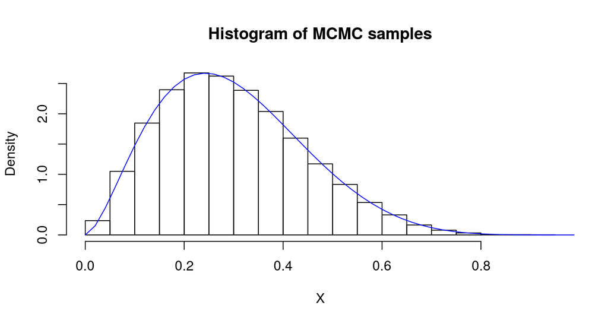

```r
## see how samples from chain compare to Beta(2.7, 6.3) density
hist(X, main = "Histogram of MCMC samples", prob = TRUE)
curve(expr = dbeta(x, 2.7, 6.3),
      from = 0, to = 2, add = TRUE, col = "blue")
```

## Example Beta(2.7, 6.3)

```r
X = numeric(N)
X[1] = rbeta(n = 1, shape1 = 2.7, shape2 = 6.3)
for(i in 1:N){
  Y = rgamma(n = 1, shape = 2.5, scale = 1/5)
  rho = (dbeta(x = Y, 2.7, 6.3) * dgamma(x = X[i], shape = 2.5, scale = 1/5) ) /
    (dbeta(x = X[i], 2.7, 6.3) * dgamma(x = Y, shape = 2.5, scale = 1/5) )

  if(runif(1) < rho){
    X[i+1] = Y
  } else{
    X[i+1] = X[i]
  }

}

quantile(X)
```

```
##          0%         25%         50%         75%        100%
## 0.002710676 0.188878363 0.284491099 0.394478021 0.922120535
```

## Example Beta(2.7, 6.3)

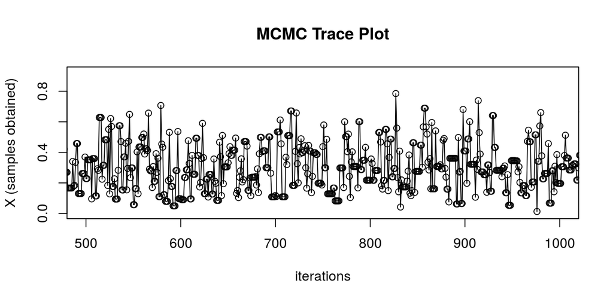

```r
## see chain transitions
plot(X, type = "o", main = "MCMC Trace Plot", xlim = c(500,1000),
     xlab = "iterations", ylab = "X (samples obtained)")
```

## Example Beta(2.7, 6.3)

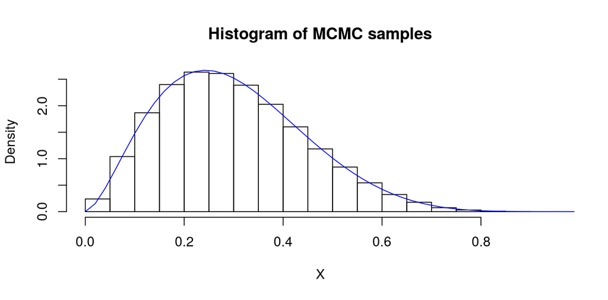

```r
## see how samples from chain compare to Beta(2.7, 6.3) density
hist(X, main = "Histogram of MCMC samples", prob = TRUE)
curve(expr = dbeta(x, 2.7, 6.3), from = 0, to = 2, add = TRUE, col = "blue")
```

## Example Beta(2.7, 6.3)

This version of the M-H algorithm is known as the **Independent Metropolis-Hastings**. This method appears a generalization of the accept-reject algorithm in the sense that the instrumental distribution is the same density \(g\) as in the accept-reject algorithm. Thus, the proposed values \(Y_i\) are the same, if not the accepted ones.

## Independent M-H

The **Independent Metropolis-Hastings algorithm** as described Robert & Casella goes as follows

Given \(x^{(t)}\)

`1. Generate` \(Y_t \sim g(y)\)

`2. Take`

\[ X_{t+1} = \begin{cases} Y_t & \quad \text{with probability }\ \rho(x^{(t)}, Y_t) \\ x^{(t)} & \quad \text{with probability }\ 1 - \rho(x^{(t)}, Y_t) \\ \end{cases} \] where \[ \displaystyle \rho(x^{(t)}, Y_t) = \text{min} \left\{ \frac{f(Y_t)}{f(x^{(t)})} \frac{g(x^{(t)})}{g(Y_t)}, 1 \right\} \]

## Independent M-H

In simpler terms, as we want to generate \(X \sim f\), we first take an initial value \(x^{(0)}\) (which can almost be any artibrary value in the support of \(f\)).

1. We generate a value \(Y_0 \sim q(y | x^{(0)})\).
2. We calculate \(\rho(x^{(t)}, Y_t)\)
3. Generate a random value \(U \sim Unif(0,1)\)
4. If \(U < \rho(x^{(t)}, Y_t)\), then we accept \(X^{(1)} = Y_t\); else we take \(X^{(1)} = X^{(0)}\)
5. Repeate steps 1-4 until you've satisfied the number of samples needed

## Example: Gamma(4.3, 6.2)

Here we will compare again the Accept-Reject algorithm against the Metropolis-Hastings. Generate *N* random variables \(X \sim Gamma(4.3, 6.2)\).

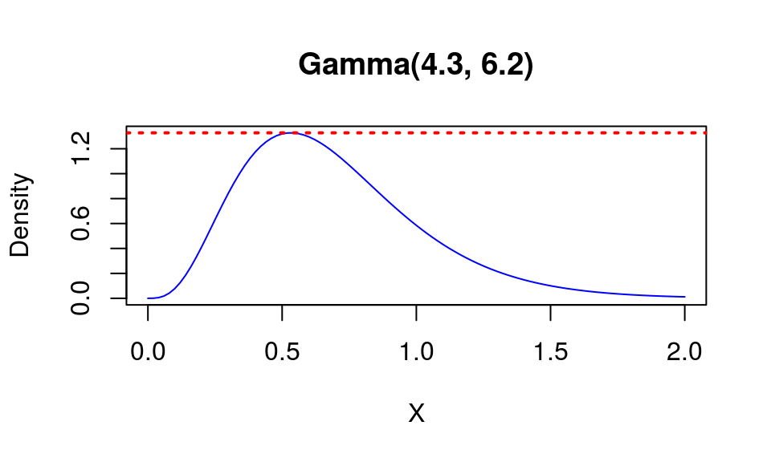

```r
## For accept-reject, we need to find a value for M
## we can use `optimize` to find the maximum of our target density
maximum  = optimize(f = function(x){ dgamma(x = x, shape = 4.3, rate = 6.2)},
                    interval = c(0, 2), maximum = TRUE ) ## obtain maximum

M = maximum$objective
curve(expr = dgamma(x = x, shape = 4.3, rate = 6.2), from = 0,
      to = 2, col = "blue", main = "Gamma(4.3, 6.2)", xlab = "X", ylab = "Density")
abline(h = M, lty = 3, lwd = 2, col = "red")
```

## Example: Gamma(4.3, 6.2)

```r
f = function(x){
  dgamma(x = x, shape = 4.3, rate = 6.2)
}

g = function(x){
  dgamma(x = x, shape = 4, rate = 7)
}

X = numeric(N)
i = 0
while(i < N){
  Y = rgamma(n = 1, shape = 4, rate = 7)
  U = runif(1)
  if(U*M <= f(Y)/g(Y)){
    i = i + 1
    X[i] = Y
  }
}
```

## Example: Gamma(4.3, 6.2)

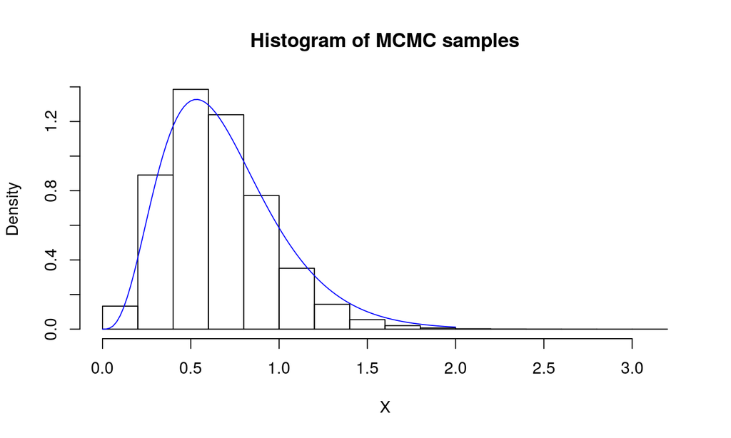

```r
## see how samples from chain compare to Gamma density
hist(X, main = "Histogram of MCMC samples", prob = TRUE)
curve(expr = dgamma(x = x, shape = 4.3, rate = 6.2),
      from = 0, to = 2, add = TRUE, col = "blue")
```

## Example: Gamma(4.3, 6.2)

```r
## Metropolis Hastings

N = 10000
X = numeric(N)
X[1] = rgamma(n = 1, shape = 4.3, rate = 6.2)
for(i in 1:N){
  Y = rgamma(n = 1, shape = 4, rate = 7)
  rho = (dgamma(x = Y, shape = 4.3, rate = 6.2) * dgamma(x = X[i], shape = 4, rate = 7)) /
    (dgamma(x = X[i], shape = 4.3, rate = 6.2) * dgamma(x = Y, shape = 4, rate = 7))
  #X[i+1] = X[i] + (Y - X[i])*(runif(1) < rho) ## equivalent to if-else statement below
  if(runif(1) < rho){
    X[i+1] = Y
  } else{
    X[i+1] = X[i]
  }
}
#qgamma(p = c(0, 0.25, 0.5, 0.75, 1), shape = 4.3, rate = 6.2) #[1] 0.0000000 0.4488888 0.6405895 0.8808118       Inf
quantile(X)  ## rgamma: 0.6979356
```

```
##         0%        25%        50%        75%       100%
## 0.06364308 0.44650858 0.63902685 0.87142726 2.58634991
```

## Example: Gamma(4.3, 6.2)

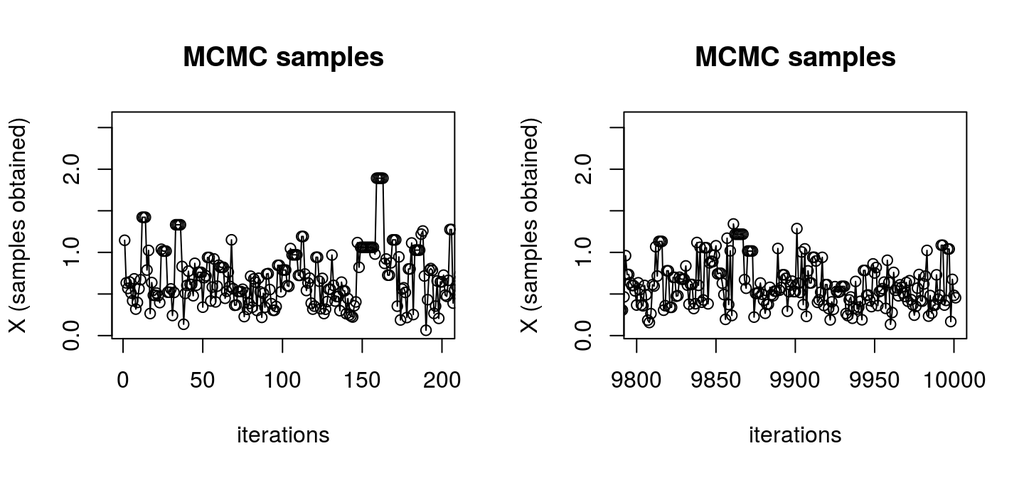

```r
## see chain transitions
par(mfrow = c(1,2))
plot(X, type = "o", main = "MCMC samples",
     xlim = c(1,200),
     xlab = "iterations", ylab = "X (samples obtained)")

plot(X, type = "o", main = "MCMC samples",
     xlim = c(N-200,N),
     xlab = "iterations", ylab = "X (samples obtained)")
```

## Example: Gamma(4.3, 6.2)

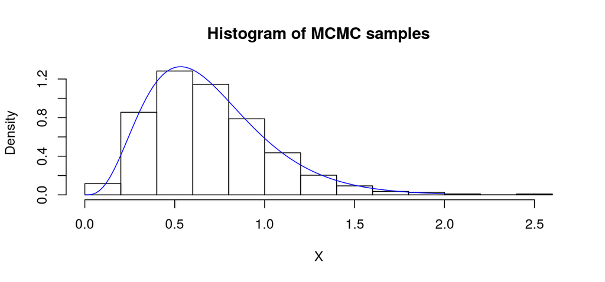

```r
## see how samples from chain compare to Gamma density
hist(X, main = "Histogram of MCMC samples", prob = TRUE)
curve(expr = dgamma(x = x, shape = 4.3, rate = 6.2),
      from = 0, to = 2, add = TRUE, col = "blue")
```

## Example: Gamma(4.3, 6.2)

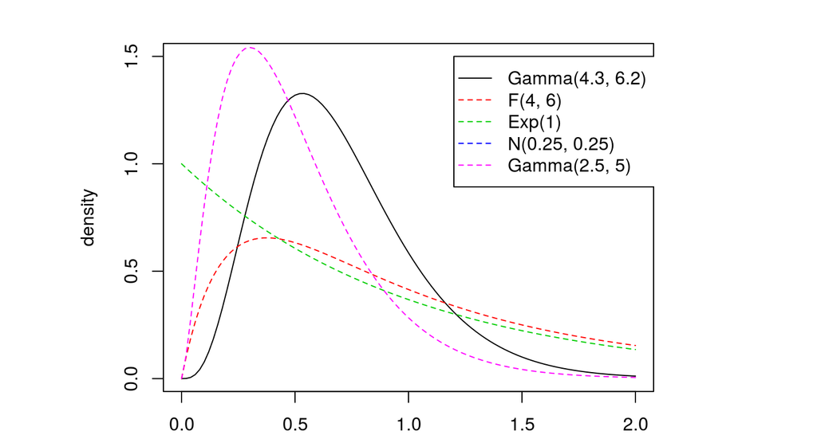

## Example: Gamma(4.3, 6.2)

```r
## Metropolis Hastings
X = numeric(N)
X[1] = 0.5
for(i in 1:N){
  Y = rf(n = 1, df1 = 4, df2 = 6)
  rho = (dgamma(x = Y, shape = 4.3, rate = 6.2) * df(x = X[i], df1 = 4, df2 = 6)) /
    (dgamma(x = X[i], shape = 4.3, rate = 6.2) * df(x = Y, df1 = 4, df2 = 6))
  #X[i+1] = X[i] + (Y - X[i])*(runif(1) < rho) ## equivalent to if-else statement below
  if(runif(1) < rho){
    X[i+1] = Y
  } else{
    X[i+1] = X[i]
  }
}
qgamma(p = c(0, 0.25, 0.5, 0.75, 0.9), shape = 4.3, rate = 6.2)
```

```
## [1] 0.0000000 0.4488888 0.6405895 0.8808118 1.1417128
```

```r
quantile(X, probs = c(0, 0.25, 0.5, 0.75, 0.9))
```

```
##        0%       25%       50%       75%       90%
## 0.0467881 0.4479436 0.6439269 0.8912774 1.1568716
```

## Example: Gamma(4.3, 6.2)

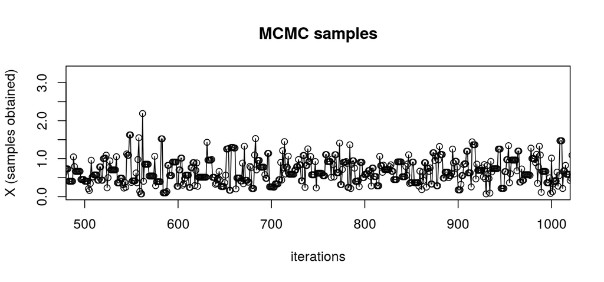

```r
## see chain transitions
plot(X, type = "o", main = "MCMC samples", xlim = c(500,1000),
     xlab = "iterations", ylab = "X (samples obtained)")
```

## Example: Gamma(4.3, 6.2)

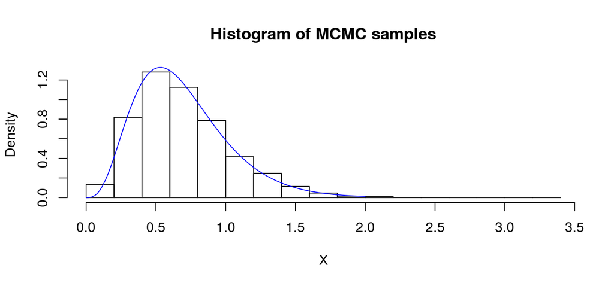

```r
## see how samples from chain compare to Gamma density
hist(X, main = "Histogram of MCMC samples", prob = TRUE)
curve(expr = dgamma(x = x, shape = 4.3, rate = 6.2), from = 0, to = 2, add = TRUE, col = "blue")
```

## Bayesian Analysis

## O-ring Challenger Data

[Bayesian Reanalysis of the Challenger O-Ring Data](http://www.calvin.edu/library/Remelts/orings.pdf)

Bayesian logistic regression

- Using a noninformative prior
- let's us use regular logistic parameters with the benefits of Bayesian interpretation

## O-ring Challenger Data

The following is a well covered logistic regression example using the O-ring data set related to the 1986 space shuttle Challenger exploision. The output is modeled as the probability of failure (Y = 1) given the data.

\[ P(Y = 1 | X = x) = p = \frac{exp(\alpha + x \beta)}{1 + exp(\alpha + x \beta)} \] Or, equivalently with the logit transformation on \(P\) \[ logit(p) = \frac{p}{1 - p} = \alpha + x \beta \]

## O-ring Challenger Data

```r
failure <- c(1, 1, 1, 1, 0, 0, 0, 0, 0, 0, 0, 0, 1, 1,
             0, 0, 0, 1, 0, 0, 0, 0, 0)
temperature <- c(53, 57, 58, 63, 66, 67, 67, 67, 68,
                 69, 70, 70, 70, 70, 72, 73, 75, 75,
                 76, 76, 78, 79, 81)

df = data.frame(failure, temperature)
head(df)
```

```
##   failure temperature
## 1       1          53
## 2       1          57
## 3       1          58
## 4       1          63
## 5       0          66
## 6       0          67
```

## O-ring Challenger Data

The frequentist logistic regression

```
##
## Call:
## glm(formula = failure ~ temperature, family = binomial(link = "logit"),
##     data = df)
##
## Deviance Residuals:
##     Min       1Q   Median       3Q      Max
## -1.0611  -0.7613  -0.3783   0.4524   2.2175
##
## Coefficients:
##             Estimate Std. Error z value Pr(>|z|)
## (Intercept)  15.0429     7.3786   2.039   0.0415 *
## temperature  -0.2322     0.1082  -2.145   0.0320 *
## ---
## Signif. codes:  0 '***' 0.001 '**' 0.01 '*' 0.05 '.' 0.1 ' ' 1
##
## (Dispersion parameter for binomial family taken to be 1)
##
##     Null deviance: 28.267  on 22  degrees of freedom
## Residual deviance: 20.315  on 21  degrees of freedom
## AIC: 24.315
##
## Number of Fisher Scoring iterations: 5
```

## O-ring Challenger Data

Observed are \[ Y_i \sim Bernoulli(p(x_i)), \text{ where } p(x_i) = \frac{exp(\alpha + x_i \beta)}{1 + exp(\alpha + x_i \beta)} \] where \(p(x_i)\) is the probability of O-ring failure at temperature \(x_i\). The likelihood is \[ L(\alpha, \beta | \mathbf{y}) \propto \prod^n_{i = 1} \left(\frac{exp(\alpha + x_i \beta)}{1 + exp(\alpha + x_i \beta)} \right)^{y_i} \times \left(\frac{ 1 }{1 + exp(\alpha + x_i \beta)} \right)^{1 - y_i} \]

and as a prior Robert & Casella choose \[ \pi_{\alpha}(\alpha | b) \times \pi_{\beta}(\beta) = \frac{1}{b} e^{\alpha} e^{- e^{\alpha} / b} \] which puts an exponential prior on \(log(\alpha)\) and a flat prior on \(\beta\) (uniform), and insures a proper posterior distribution. Note that priors on \(\alpha\) and \(\beta\) are independent. This will be important for computational purposes in the M-H algorithm.

The prior above is an exponential distribution with \(Exp(\lambda)\), where \(\lambda = \frac{1}{b} e^{\alpha}\)

## O-ring Challenger Data

```r
## Output from ML estimation from Logistic Regression
## MLEs make great starting valules
a.mle <- as.numeric(fit$coefficients[1])
b.mle <- as.numeric(fit$coefficients[2])
var.a.mle <- summary(fit)$cov.scaled[1, 1]
var.b.mle <- summary(fit)$cov.scaled[2, 2]

b.hyper <- exp(a.mle + 0.577216) ## hyper parameter
## 0.577216 is "Euler’s constant"
```

## O-ring Challenger Data

Let's set up the posterior and proposal distributions

```r
## setting up functions

# Posterior distribution
dPosterior <- function(theta, y = failure, x = temperature){
    ## density of Y is binomial/bernoulli
    a <- theta[1]
    b <- theta[2]
    p <- 1 - 1 / (1 + exp(a + b * x)) ## logistic CDF
    lik <- exp(sum(dbinom(y, size=1, prob=p, log=TRUE)))
    dprior <- exp(a) * exp(-exp(a) / b.hyper) * 1/b.hyper ## density of prior
    return(lik * dprior)
}
```

## O-ring Challenger Data

```r
# Proposal distribution (independent proposal, so "theta0" is not used)
dProposal <- function(theta){
    ## ignore theta0
    a <- theta[1]
    b <- theta[2]
    # a <- log(rexp(1, 1 / b.hyper)) ## remember, log for computational purposes
    # try: exp(rexp(1, 1/b.hyper)) ## Inf
    pr1 <- exp(a) * exp(-exp(a) / b.hyper) * 1/b.hyper
    pr2 <- dnorm(b, b.mle, sqrt(var.b.mle))
    return(pr1 * pr2)
}
```

## O-ring Challenger Data

```r
rProposal <- function(theta0){
    ## independent proposals for a and b
    #a <- log(rexp(1, 1 / b.hyper))
    a <- log(rexp(1, 1 / b.hyper)) ## log for computational purposes
    b <- rnorm(1, b.mle, sqrt(var.b.mle))
    return(c(a, b))
}
```

## O-ring Challenger Data

Now we run the M-H algorithm

```r
## Metropolis-Hastings set up to run
# Run Metropolis-Hastings
N = 1000000
BurnIn =  5000
```

## O-ring Challenger Data

Code not shown here. Provided in seperate document.

Uses regular Metropolis Hastings algorithm

## O-ring Challenger Data

```r
print("acceptance rate: ")
```

```
## [1] "acceptance rate: "
```

```r
print(accept/(N+BurnIn))
```

```
## [1] 0.09512438
```

```r
MH.Results <- x[-(1:BurnIn), ]
alphaMH <- MH.Results[,1]
betaMH <- MH.Results[,2]
```

## O-ring Challenger Data

### Summary

```r
summary(MH.Results) ## summary of parameters
```

```
##        V1               V2
##  Min.   : 4.962   Min.   :-0.30365
##  1st Qu.:14.430   1st Qu.:-0.24739
##  Median :15.276   Median :-0.23582
##  Mean   :15.087   Mean   :-0.23372
##  3rd Qu.:15.957   3rd Qu.:-0.22248
##  Max.   :18.012   Max.   :-0.09881
```

## O-ring Challenger Data

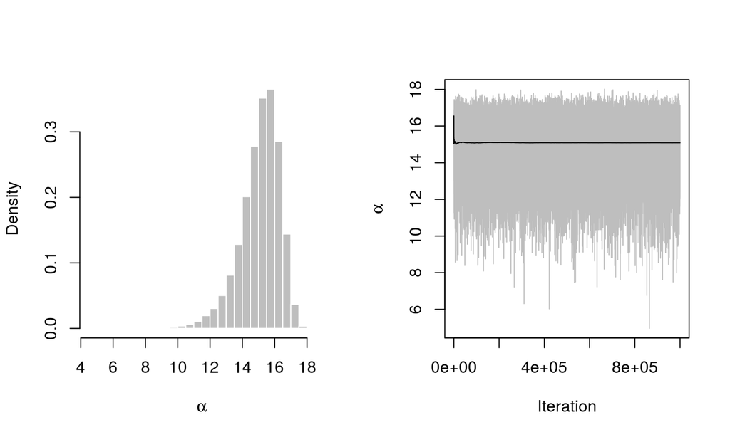

## O-ring Challenger Data

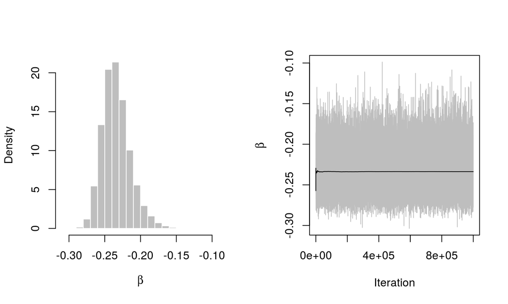

## Exercise Student's t density with v degrees of freedom

Calculate the mean of a t distribution with \(v = 4\) degrees of freedom using a M-H algorithm with candidate densities \(N(0,1)\) and \(t_{v = 2}\).

## Appendix

## Solution to Student's t density with v degrees of freedom

```r
set.seed(987)
N = 10^6

#dt(x = x, df = 4)

X = numeric(N)
X[1] = rnorm(1) ## initialize the starting value

for(i in 1:N){
    Y = rnorm(1) ## independent of X_i
    rho = (dt(Y, df = 4) * dnorm(X[i])) /
            (dt(X[i], df = 4) * dnorm(Y))
    U = runif(1)
    if(U <= rho){
        X[i+1] = Y
    } else{
        X[i+1] = X[i]
    }

}
```

## Solution to Student's t density with v degrees of freedom

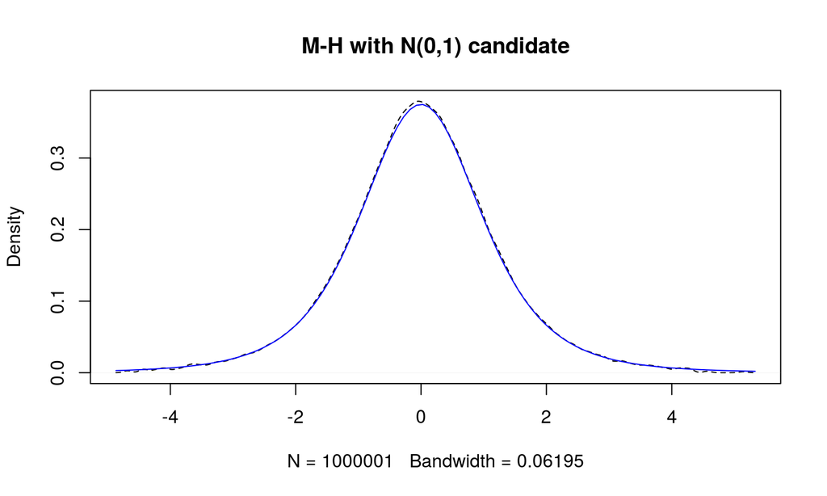

```r
plot(density(X), type = "l",
        lty = 2, main = "M-H with N(0,1) candidate")
curve(dt(x, df = 4), add = TRUE, col = 4)
```